# 個人的な📝

[**GitHub Pages**](https://docs.github.com/ja/pages/getting-started-with-github-pages/about-github-pages)**にRmarkdownから生成したhtmlファイルを公開する手順**

- GitHub リポジトリ名はgithub.ioをつける
- リポジトリのvisibilityはpublicにすること
- ファイル名は`index.Rmd`とする

# 設定の変更

gitコマンドはデフォルトでファイル名の大文字・小文字の変更は検知しない設定になっているので変更する

```bash
git config core.ignorecase false
git config -l --local | grep core.ignorecase
```

# ローカルリポジトリの作成

作業ディレクトリを作成する

```bash
mkdir git_memo && cd $_

git init

git status
```

# RMarkDownのレンダリング

index.Rmdファイルからindex.htmlを生成する、RStudioからは`⌘` + `shift` + `k`がショートカット

```r
rmarkdown::render(input = 'index.Rmd')
```

# GitHubにリポジトリを作成

[gh](https://cli.github.com/manual/)コマンドでリモートリポジトリを作成

```bash
gh repo create git_memo.github.io  --public -d 'githubの使い方のメモ'

# 確認
gh repo list
```

# リポートリポジトリのリンク

```bash
git remote add origin https://github.com/kawaitel/git_memo.github.io
# 確認
git remote -v
```

# リポジトリにプッシュ

```bash
git add .
git add README.md
git commit -m "first commit"
git push -f origin main
```

# GitHub Pagesの設定

レポジトリの`Settings`から**Pages**を選び**Branch**を`main`に変更する

[figure not shown]

**warning** リモートリポジトリのブランチ名は`main`である前提です

これで無事、RmarkdownからHtmlファイルを生成して、静的WebサイトとしてGitHub Pagesに公開できたと思います

# memo

このページの右上の`Code` ボタンを押すとこのページを生成したindex.Rmdファイルをダウンロードすることができます。 (Safariでは動作しません)

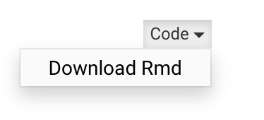

ダウンロードされたindex.Rmd単独でレンダリングすると、ファビコンを指定したファイルがリンクできないのでエラーになります。このリポジトリをgit cloneしてレンダリングしてください

# Links

公開されたGitHub Pagesは

https://kawaitel.github.io/git_memo.github.io

このリポジトリは

https://github.com/kawaitel/git_memo.github.io

Gitの解説（わかりやすい）

https://github.com/kaityo256/github